# 02_numpy-hw-solutions-cut

```python
import numpy as np

import matplotlib.pyplot as plt

%matplotlib inline
```

## Индексация (3.75 балла)

Найдите все индексы, где достигаются максимумы по строке в массиве $B$. **(0.5 балла)**

**Подсказка:** `np.argmax` тут не подойдет. Почему?

```python
B = [[0, 0, 3, 1, 3, 2],
     [2, 3, 0, 0, 3, 0],
     [0, 1, 2, 0, 0, 2],
     [2, 0, 2, 0, 2, 1],
     [1, 1, 0, 0, 1, 3]]
B = np.asarray(B)
B
```

```
array([[0, 0, 3, 1, 3, 2],
       [2, 3, 0, 0, 3, 0],
       [0, 1, 2, 0, 0, 2],
       [2, 0, 2, 0, 2, 1],
       [1, 1, 0, 0, 1, 3]])
```

```python
np.where(B == B.max(axis=1)[:,np.newaxis])
```

```
(array([0, 0, 1, 1, 2, 2, 3, 3, 3, 4]), array([2, 4, 1, 4, 2, 5, 0, 2, 4, 5]))
```

Рассмотрим массив $A$. Модифицруйте предыдущее решение так, чтобы получился массив $C$ следующего вида **(0.5 балла)**:

- значения в матрице $C$ на позициях, где условие выполнено, совпадает со значениями на позициях в матрице $A$;
- иначе – `-np.inf`.

Сохраните результат в переменную $C$.

```python
A = [[3, 1, 4, 5, 1, 2],
     [3, 3, 2, 4, 2, 2],
     [4, 1, 0, 1, 0, 2],
     [1, 0, 4, 3, 4, 3],
     [4, 2, 0, 1, 3, 4]]
A = np.asarray(A)
A
```

```
array([[3, 1, 4, 5, 1, 2],
       [3, 3, 2, 4, 2, 2],
       [4, 1, 0, 1, 0, 2],
       [1, 0, 4, 3, 4, 3],
       [4, 2, 0, 1, 3, 4]])
```

```python
C = np.where(B == B.max(axis=1)[:,np.newaxis], A, -np.inf)
C
```

```
array([[-inf, -inf,   4., -inf,   1., -inf],
       [-inf,   3., -inf, -inf,   2., -inf],
       [-inf, -inf,   0., -inf, -inf,   2.],
       [  1., -inf,   4., -inf,   4., -inf],
       [-inf, -inf, -inf, -inf, -inf,   4.]])
```

Найдите индексы, где $C$ принимает наибольшие значения. **(0.25 балла)**

**Замечание:** помните о том, что `C.dtype == dtype('float')`, и числа с плавующей точкой нельзя сравнивать через `==`.

```python
np.where(np.isclose(C, C.max()))
```

```
(array([0, 3, 3, 4]), array([2, 2, 4, 5]))
```

## Операции над массивами (4.5 балла)

```python
np.random.seed(4589)

X = np.random.randint(0, 2, size=(5, 10))
X
```

```
array([[0, 1, 1, 0, 1, 0, 1, 1, 1, 0],
       [1, 0, 0, 1, 0, 0, 1, 0, 1, 0],
       [0, 1, 0, 0, 0, 1, 1, 1, 0, 1],
       [1, 1, 0, 0, 0, 1, 1, 1, 0, 1],
       [0, 0, 0, 1, 1, 1, 0, 1, 1, 0]])
```

Отнормируйте столбцы массива $X$ по $l1$-норме. **(0.25 балла)**

```python
# best variant: sklearn.preprocessing.normalize
# normalize(X, norm='l1', axis=0)

X / np.linalg.norm(X, ord=1, axis=0)
```

```
array([[0.        , 0.33333333, 1.        , 0.        , 0.5       ,
        0.        , 0.25      , 0.25      , 0.33333333, 0.        ],
       [0.5       , 0.        , 0.        , 0.5       , 0.        ,
        0.        , 0.25      , 0.        , 0.33333333, 0.        ],
       [0.        , 0.33333333, 0.        , 0.        , 0.        ,
        0.33333333, 0.25      , 0.25      , 0.        , 0.5       ],
       [0.5       , 0.33333333, 0.        , 0.        , 0.        ,
        0.33333333, 0.25      , 0.25      , 0.        , 0.5       ],
       [0.        , 0.        , 0.        , 0.5       , 0.5       ,
        0.33333333, 0.        , 0.25      , 0.33333333, 0.        ]])
```

Даны два небольших массива $A$ размера $M \times N$ и $B$ размера $K \times N$.

Напишите функцию `find_equal_lines(A, B)`, которая найдет все индексы строк массива $A$, содержащиеся в $B$.

**Запрещается** использовать циклы. **(1 балл)**

**Подсказка**: попробуйте поэкспериментировать с размерностью массивов $A$ и $B$.

```python
def find_equal_lines(A, B):
    mask = (A[:,np.newaxis,:] == B[np.newaxis,:,:]).all(axis=2).any(axis=1)
    return np.where(mask)[0]
```

```python
A = np.array([
    [1, 2, 3],
    [1, 2, 1],
    [4, 5, 6],
    [1, 2, 1],
])

B = np.array([
    [4, 5, 6],
    [4, 5, 6],
    [1, 2, 3],
])

indices = find_equal_lines(A, B)

assert (indices == [0, 2]).all()
```

#### Небольшой набор задачек про изображение

```python
# Если у вас не получается скачать изображение с помощью этого кода, можете скачать его в ручную.
# Сохраните картинку рядом с этим ноутбуком и назовите image.jpg

import urllib.request

urllib.request.urlretrieve(
    'https://upload.wikimedia.org/wikipedia/commons/thumb/3/33/Prokudin-Gorskii-19.jpg/555px-Prokudin-Gorskii-19.jpg',
    'image.jpg'
)
```

```
('image.jpg', <http.client.HTTPMessage at 0x1194ed438>)
```

```python
# Install package if it doesn't exist
# !pip install imageio
```

```python
import imageio

def plot_image(img, zoom=1.5):
    assert 2 <= len(img.shape) <= 3

    n_len = 6.5

    n, m = img.shape[:2]
    frac = n / float(m)
    n, m = zoom * frac * n_len, zoom * n_len

    fig = plt.figure(figsize=(n, m))
    ax = fig.add_subplot(111)
    ax.imshow(img)
    ax.axis('off')
    plt.show()
```

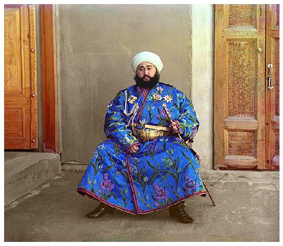

```python
img = imageio.imread('image.jpg')
plot_image(img, zoom=1.5)
```

Найдите среднее значению по каждому из каналов RGB. **(0.25 балла)**

```python
img.mean(axis=(0, 1))
```

```
array([139.68829204, 119.95454955, 104.70236862])
```

Посчитайте разброс (среднеквадратичное отклонение) значений по каждому из каналов. **(0.25 балла)**

```python
img.std(axis=(0, 1))
```

```
array([54.88760236, 49.51637085, 53.98533328])
```

Поменяйте каналы в обратном порядке. Сохраните результат в переменную img. **(0.25 балла)**

```python
img = img[:,:,::-1]
```

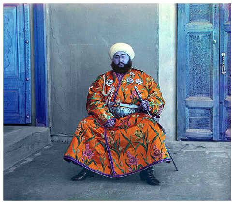

```python
plot_image(img, zoom=1.5)
```

## Случайный классификатор (1.75 балла)

**Случайный классификатор**

```python
from sklearn.base import ClassifierMixin

class RandomClassifier(ClassifierMixin):
    def __init__(self, n_classes=2, seed=8888):
        self.n_classes = n_classes
        self.seed = seed

    def fit(self, X, y=None):
        return self

    def predict_proba(self, X, y=None):
        """
        Method returns np.ndarray y:
            y.shape == (X.shape[0], n_classes)

        y satisfies:
            sum y[i, j] where j in {0..n_classes-1} = 1
        """

        np.random.seed(self.seed)

        X = np.asarray(X)
        y = np.random.rand(X.shape[0], self.n_classes)
        y /= np.expand_dims(y.sum(axis=1), axis=1)

        return y

    def predict(self, X, y=None):
        # raise NotImplementedError('Code your realisation here')

        y_pred = self.predict_proba(X)
        return y_pred.argmax(axis=1)
```

```python
cls = RandomClassifier(n_classes=3, seed=3492)

X = list(range(100))
y_pred = cls.predict_proba(X)

y_pred.shape
```

```
(100, 3)
```

Убедитесь, что классификатор реализован правильно, т.е. сумма вероятностей для каждого примера из выборки равна 1.0. **(0.25 балла)**

Для сравнения с 1.0 используйте функцию `np.isclose` или `np.allclose`. Ваша проверка должна иметь вид:

```
assert your_condition
```

```python
assert np.allclose(y_pred.sum(axis=1), 1.0)
```

Для каждого примера из выборки найдите класс-победитель, реализуйте эту логику в методе `predict`. **(0.25 балла)**

```python
y_true = np.array([2, 0, 1, 1, 2, 0, 2, 1, 0, 1, 2, 1, 1, 1, 2, 2, 1, 2, 1, 0, 0, 1,
                   2, 0, 0, 1, 0, 2, 2, 2, 0, 2, 1, 0, 0, 1, 1, 2, 2, 1, 2, 2, 1, 2,
                   0, 2, 2, 0, 1, 1, 0, 1, 2, 1, 1, 2, 0, 1, 1, 2, 0, 2, 2, 0, 0, 0,
                   1, 0, 2, 1, 1, 2, 0, 0, 0, 2, 1, 0, 2, 0, 0, 2, 0, 0, 1, 2, 1, 0,
                   0, 0, 2, 1, 1, 1, 0, 0, 2, 1, 1, 1])

y_pred = cls.predict(X)

assert (y_pred == y_true).all()
```

Найдите количество примеров в каждом классе. **(0.25 балла)**

```python
np.unique(y_pred, return_counts=True)
```

```
(array([0, 1, 2]), array([33, 35, 32]))
```

Напишите метрику LogLoss: **(0.25 балла)**

$$ LogLoss(y, p) = - y log(p) - (1 - y) log(1 - p) $$

- $y$ – истинная метка класса (0 или 1);
- $p$ – предсказанная вероятность того, что объект пренадлежит классу 1.

$$ LogLoss = \frac{1}{N} \sum\limits_{i=1}^N LogLoss(y_i, p_i) $$

```python
def logloss(y_true, y_pred):
    """
    Функция возвращает усредненный лог-лосс для всех точек, см. последнюю формулу.
    """
    return (- y_true * np.log(y_pred) - (1 - y_true) * np.log(1 - y_pred)).mean()
```

```python
from sklearn.metrics import log_loss

cls = RandomClassifier(n_classes=2, seed=5498)

X = list(range(100))
y_pred = cls.predict_proba(X)[:,1]
y_true = (np.random.random(len(X)) > 0.5).astype(int)

score = logloss(y_true, y_pred)
assert np.allclose(score, log_loss(y_true, y_pred))

score
```

```
0.7784479439646758
```

**Случайный регрессор**

```python
from sklearn.base import RegressorMixin

class RandomRegressor(RegressorMixin):
    def __init__(self, seed=8888):
        self.seed = seed

    def fit(self, X, y=None):
        return self

    def predict(self, X, y=None):
        """
        Method returns np.ndarray y:
            y.shape == (X.shape[0], )
        """

        np.random.seed(self.seed)

        X = np.asarray(X)
        y = np.random.rand(X.shape[0])
        y = 2 * (y - 0.5)

        return y
```

Напишите метрику MSE: **(0.25 балла)**

$$ MSE = \frac{1}{N} \sum\limits_{i=1}^{N} (y_i - \hat y_i) ^ 2 $$

- $y_i$ – истиное значение для i-го примера;
- $\hat y_i$ – предсказанное значение для i-го примера.

```python
def mse(y_true, y_pred):
    return np.power(y_true - y_pred, 2).mean()
```

```python
from sklearn.metrics import mean_squared_error

reg = RandomRegressor(seed=5498)

X = list(range(100))
y_pred = reg.predict(X)
y_true = 2 * ((np.random.random(len(X)) > 0.5).astype(int) - 0.5)

score = mean_squared_error(y_true, y_pred)
assert np.allclose(score, mse(y_true, y_pred))

score
```

```
1.3044196445037217
```

**Голосование**

Предположим, что мы используем набор из `K` различных классификаторов. Результаты работы классификаторов для `N` объектов хранятся в массиве `y_pred`, `y_pred.shape = (N, K)`.

Требуется провести обычное голосование для каждого из объектов и выбрать метку-победитель (метка, встретившаяся для данного объекта наибольшее число раз). Если меток-победителей несколько, допустимо выбрать любую. **(0.5 балла)**

```python
np.random.seed(9866)

y_pred = np.random.randint(0, 3, size=(10, 5))
y_pred
```

```
array([[2, 0, 2, 0, 2],
       [1, 2, 0, 0, 0],
       [2, 0, 1, 1, 2],
       [0, 1, 1, 0, 0],
       [2, 2, 1, 2, 0],
       [1, 2, 2, 1, 0],
       [0, 0, 2, 1, 0],
       [2, 0, 0, 2, 1],
       [1, 1, 0, 1, 1],
       [1, 1, 1, 2, 0]])
```

```python
np.apply_along_axis(lambda r: np.bincount(r).argmax(), 1, y_pred)
```

```
array([2, 0, 1, 0, 2, 1, 0, 0, 1, 1])
```

```python
# other variant

import scipy

scipy.stats.mode(y_pred, axis=1).mode.flatten()
```

```
array([2, 0, 1, 0, 2, 1, 0, 0, 1, 1])
```

## Снежинка Коха (1 балл)

В этом задании предлагается поэтапно научиться строить фрактал [Снежинку Коха](https://en.wikipedia.org/wiki/Koch_snowflake).

[figure not shown]

### Небольшое напоминание про компле́ксные числа.

Комплексным числом $z$ называется упорядоченная пара действительных чисел $(x, y); x, y \in \mathbb{R}$. Число $x$ называется действительной частью $z$, а число $y$ – мнимой частью числа $z$. Для них приняты следующие обозначения: $x = \text{Re}(z)$; $y = \text{Im}(z)$.

Множество комплексных чисел обозначается $\mathbb{C}$ (комплексная плоскость). Комплексное число $z$ можно интерпретировать как точку $(x, y)$ на комплексной плоскости.

Мнимой единицей называется комплексное число $i = (0, 1)$. Таким образом, число $z$ можно записать, как $$z = x + i y$$

Сопряженным к комплексному числу $z$ называется комплексное число $$\hat z = x - i y$$

Модулем комплексного числа $z$ называется $$|z| = \sqrt{x ^ 2 + y ^ 2}$$

Угол $\varphi$, составленный между точкой $z \ne 0$ и положительным направленим полуоси $Ox$, называется аргументом числа $z$. Аргумент числа $z$ определен с точностью до $2 \pi n$: $$ \text{Arg} z = \{ \varphi + 2 \pi n; n \in Z \} $$

Число $\varphi_0 = \varphi \in (-\pi; \pi]$ – называется главным аргументом числа $z$.

Если $\varphi \in \text{Arg} z$, то имеет место представление: $$ z = |z| (\cos \varphi + i \sin \varphi) $$

Используя формулу Эйлера $e^{i \varphi} = \cos \varphi + i \sin \varphi$ имеем $$z = |z| e ^ {i \varphi}$$

Пусть $$ z_1 = x_1 + i y_1 = |z_1| e ^ {i \varphi_1} $$ $$ z_2 = x_2 + i y_2 = |z_2| e ^ {i \varphi_2} $$

Несколько важных свойств комплексных чисел:

- $z_1 \pm z_2 = (x_1 \pm x_2) + i (y_1 \pm y_2)$;
- $z_1 \cdot z_2 = (x_1 x_2 - y_1 y_2) + i (x_1 y_2 + x_2 y_1) = |z_1| |z_2| e ^ {i (\varphi_1 + \varphi_2)} $;
- $z_1 / z_2 = |z_1| / |z_2| e ^ {i (\varphi_1 - \varphi_2)} $;
- $z^n = |z|^n e ^ {i n \varphi} = |z| ^ n (\cos {n \varphi} + i \sin {n \varphi}), n \in \mathbb{Z}$ – формула Муавра-Лапласса.

Корнем $n$-й степени ($n \in \mathbb{N}$) из комплексного числа $z$ называется комплексное число $z_k^n$: $(z_k)^n = z$. В случае $z \ne 0$ имеем $n$ различных корней:

$$ z_k^n = |z|^{1/n} e ^ {i (\varphi + 2 \pi k) / n}; k \in \overline {0, n-1} $$

**Шаг 1:** Напишите функцию, которая извлекает корень из 1. **(0.25 балла)**

```python
def complex_roots(n):
    angles = np.linspace(0, 2 * np.pi, n, endpoint=False)
    return np.exp(angles * 1j)

roots = complex_roots(5)
roots
```

```
array([ 1.        +0.j        ,  0.30901699+0.95105652j,
       -0.80901699+0.58778525j, -0.80901699-0.58778525j,
        0.30901699-0.95105652j])
```

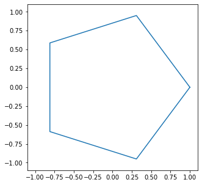

```python
roots = np.concatenate([roots, [roots[0]]])

plt.figure(figsize=(5, 5))
plt.xlim(-1.1, 1.1)
plt.ylim(-1.1, 1.1)
plt.plot(roots.real, roots.imag)
plt.show()
```

**Шаг 2:** Напишите функцию, которая строит кривую Коха 1-го порядка. **(0.25 балла)**

```python
def koch_curve():
    arr = [0, 1/3, 0.5 + 0.5j * np.sqrt(3) / 3, 2/3, 1]
    return np.asarray(arr)[::-1]

curve = koch_curve()
curve
```

```
array([1.        +0.j        , 0.66666667+0.j        ,
       0.5       +0.28867513j, 0.33333333+0.j        ,
       0.        +0.j        ])
```

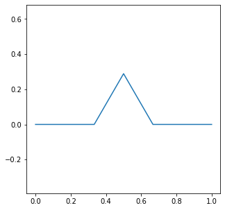

```python
plt.figure(figsize=(5, 5))
plt.axis('equal')
plt.plot(curve.real, curve.imag)
plt.show()
```

**Шаг 3:** Заменим стороны в пятиугольнике выше на кривые Коха первого порядка. **(0.5 балла)**

```python
def change_edges_to_koch_curves(vertices):
    curve = koch_curve()[:-1]

    p1 = vertices
    p2 = np.roll(p1, shift=1)
    dp = p2 - p1

    point = p1[:,np.newaxis] + dp[:,np.newaxis] * curve[np.newaxis,:]
    return point.ravel()

vertices = complex_roots(5)
line = change_edges_to_koch_curves(vertices)
line.shape
```

```
(20,)
```

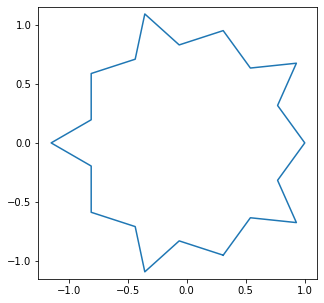

```python
line = np.concatenate([line, [line[0]]])

plt.figure(figsize=(5, 5))
plt.axis('equal')
plt.plot(line.real, line.imag)
plt.show()
```

**Шаг 4:** Построим снежинку Коха.

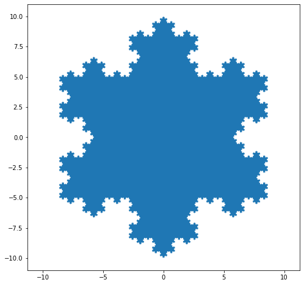

```python
def koch_snowflake(order, scale=10):
    def _koch_snowflake_complex(order):
        if order == 0:
            vertices = complex_roots(3) * 1j
        else:
            vertices = _koch_snowflake_complex(order - 1)
            vertices = change_edges_to_koch_curves(vertices)
        return vertices

    points = scale * _koch_snowflake_complex(order)
    x, y = points.real, points.imag
    return x, y

x, y = koch_snowflake(order=5)

plt.figure(figsize=(8, 8))
plt.axis('equal')
plt.fill(x, y)
plt.show()
```

## Ранжирование и сортировка (1.25 балла)

```python
import scipy.sparse

def load_array(filename, sparse=False, **params):
    with open(filename, 'rb') as f_data:
        load = scipy.sparse.load_npz if sparse else np.load
        return load(f_data, **params)
```

```python
lightfm_domain_source_ranks = load_array('lightfm_domain_source_ranks.npy')
lightfm_domain_source_ranks.shape
```

```
(14823, 3715)
```

```python
np.random.seed(42)
noise = 0.5 * (1 + np.random.random(size=lightfm_domain_source_ranks.shape))
lightfm_domain_source_ranks += noise
```

Массив имеет размерность `lightfm_domain_source_ranks.shape = (n_domains, n_sources)`.

```python
%%time

def get_best_ranks_slow(ranks, top=10, return_ranks=False):
    indices = ranks.argsort(axis=1)[:,:-top-1:-1]
    result = (indices, )

    if return_ranks:
        ranks = np.sort(ranks, axis=1)[:,:-top-1:-1]
        result += (ranks, )

    return result if len(result) > 1 else result[0]

indices_result = get_best_ranks_slow(lightfm_domain_source_ranks, top=15)
```

```
CPU times: user 2.9 s, sys: 128 ms, total: 3.02 s
Wall time: 3.03 s
```

**Шаг 1: (0.25 балла)**

Напишите функцию `get_best_ranks(ranks, top=10)`, которая для каждого `domain` (строчки) выводит `top` индексов `sources` (столбцов), в которых значение `ranks` максимально.

Результат вашей функции должен быть результату работы `get_best_ranks_slow` быть может только за исключением порядка самих индексов в строках.

**Замечание по реализации:** реализация приведенная выше неэффективна, сортировка работает за `O(N log(N))`. Приведите решение, которое работает за `O(N)`, где `N` – размер исходного массива.

**Подсказка:** google "get indexes of n maximum values"

**Шаг 2: (0.5 балла)**

Модифицируйте ваше решение, добавив в функцию сортировку так, чтобы результат работы функции `get_best_ranks` **в точности совпадал** с результатом работы функции `get_best_ranks_slow`. Приведите решение, которое работает за `O(N) + O(K log(K))`, где `N` – размер исходного массива, а `K` – число элементов в топе.

**Замечание:** легко убедиться в том, что такое решение не улучшает асимптотику в смысле O-большого. Положим $K = a N; a \in (0, 1]$, тогда

$$ O(K \log K) = O(a \cdot N \cdot \log(a \cdot N)) = \ O(a N \cdot (\log a + \log N) = \ O(a \cdot \log a \cdot N + a \cdot N \cdot \log N) = \ O(N \log N) $$

Однако она зависит от константы $a$, поэтому такой вариант реализации работает быстрее, чем реализация `get_best_ranks_slow`.

**Шаг 3: (0.5 балла)**

Поддержите в функции `get_best_ranks` аргумент `return_ranks=True`. В этом случае функция должна возвращать еще и значения ранков, см. реализацию `get_best_ranks_slow`.

**Замечание:** поддержка аргумента не должна приводить к увеличению сложности, т.е. реализация в функции `get_best_ranks_slow` неверная.

```python
_, ranks_result = get_best_ranks_slow(lightfm_domain_source_ranks, top=15, return_ranks=True)
```

```python
%%time

def get_best_ranks(ranks, top=10, return_ranks=False):
    indices = np.argpartition(ranks, -top, axis=1)[:,-top:]
    ranks_top = np.take_along_axis(ranks, indices, axis=1)
    indices = np.take_along_axis(indices, ranks_top.argsort(axis=1)[:,::-1], axis=1)
    result = (indices, )

    if return_ranks:
        ranks = np.take_along_axis(ranks, indices, axis=1)
        result += (ranks, )

    return result if len(result) > 1 else result[0]

_, ranks = get_best_ranks(lightfm_domain_source_ranks, top=15, return_ranks=True)
```

```
CPU times: user 685 ms, sys: 184 ms, total: 870 ms
Wall time: 873 ms
```

```python
assert np.isclose(ranks, ranks_result).all()
```